# Pyspark_Project_with_ML(final)

## Group Name H1

## Group Member Name: Ukash Bhat

```python
import numpy as np
import matplotlib.pyplot as plt
import seaborn as sns
```

```python
import findspark
findspark.init("/usr/local/spark/")
import pyspark
```

```python
from pyspark.sql import *
from pyspark.sql import functions as F
from pyspark.sql.types import *
from pyspark.ml.classification import GBTClassificationModel,GBTClassifier
from pyspark.ml.feature import VectorAssembler
from pyspark.ml.feature import StandardScaler,Normalizer
from pyspark.ml import Pipeline
from pyspark.sql.functions import *
```

```python
from pyspark.sql import SparkSession
appName = "PySpark Project1"


spark = SparkSession.builder.appName(appName).enableHiveSupport().getOrCreate()
```

### Note:

```
    Reading in the data.
```

```python
data="Customer_and_bank details_p1.csv"
data_campaign = "Customer_campaign_details_p1.csv"
data_citymaster="City_Master.csv"
data_postalcode="Customer_Postal_Code_details.csv"
data_response="Customer_Response_data_p1.csv"
data_socioeco="Customer_social_economic_data_p1.csv"
data_regionmaster="Region_code_master.csv"
data_statemaster="State_Master.csv"
###-------- loading data into dataframes:
df_main = spark.read.format('csv').option("header","true").option("inferSchema","true").option("delimiter",",").load(data).cache()
df_campaign = spark.read.format('csv').option("header","true").option("inferSchema","true").option("delimiter",",").load(data_campaign).cache()
df_citymaster = spark.read.format('csv').option("header","true").option("inferSchema","true").option("delimiter",",").load(data_citymaster).cache()
df_postalcode = spark.read.format('csv').option("header","true").option("inferSchema","true").option("delimiter",",").load(data_postalcode).cache()
df_response = spark.read.format('csv').option("header","true").option("inferSchema","true").option("delimiter",",").load(data_response).cache()
df_socioeco = spark.read.format('csv').option("header","true").option("inferSchema","true").option("delimiter",",").load(data_socioeco).cache()
df_regionmaster = spark.read.format('csv').option("header","true").option("inferSchema","true").option("delimiter",",").load(data_regionmaster).cache()
df_statemaster = spark.read.format('csv').option("header","true").option("inferSchema","true").option("delimiter",",").load(data_statemaster).cache()
```

### Note:

```
Let us view 5 rows from each dataframe.
```

```python
print(df_main.show(5))
print(df_campaign.show(5))
print(df_citymaster.show(5))
print(df_postalcode.show(5))
print(df_regionmaster.show(5))
print(df_response.show(5))
print(df_socioeco.show(5))
print(df_statemaster.show(5))
```

```
+-----------+---+-----------+-------+-------------------+-------+-------+----+-----------+----------+---------+
|Customer_id|age|        job|marital|          education|default|housing|loan|Region_Code|State_Code|City_Code|
+-----------+---+-----------+-------+-------------------+-------+-------+----+-----------+----------+---------+
|          1| 56|   services|married|        high.school|     no|     no| yes|          3|        S1|       C1|
|          2| 45|   services|married|           basic.9y|unknown|     no|  no|          3|        S1|       C1|
|          3| 59|     admin.|married|professional.course|     no|     no|  no|          4|        S2|       C2|
|          4| 41|blue-collar|married|            unknown|unknown|     no|  no|          3|        S3|       C3|
|          5| 24| technician| single|professional.course|     no|    yes|  no|          3|        S3|       C3|
+-----------+---+-----------+-------+-------------------+-------+-------+----+-----------+----------+---------+
only showing top 5 rows

None
+-----------+---------+-----+-----------+--------+--------+-----+--------+-----------+
|Customer_id|  contact|month|day_of_week|duration|campaign|pdays|previous|   poutcome|
+-----------+---------+-----+-----------+--------+--------+-----+--------+-----------+
|          1|telephone|  may|        mon|     307|       1|  999|       0|nonexistent|
|          2|telephone|  may|        mon|     198|       1|  999|       0|nonexistent|
|          3|telephone|  may|        mon|     139|       1|  999|       0|nonexistent|
|          4|telephone|  may|        mon|     217|       1|  999|       0|nonexistent|
|          5|telephone|  may|        mon|     380|       1|  999|       0|nonexistent|
+-----------+---------+-----+-----------+--------+--------+-----+--------+-----------+
only showing top 5 rows

None
+---------+---------------+----------+
|City_Code|      City_Name|State_Code|
+---------+---------------+----------+
|       C1|      Henderson|        S1|
|       C2|    Los Angeles|        S2|
|       C3|Fort Lauderdale|        S3|
|       C4|        Concord|        S4|
|       C5|        Seattle|        S5|
+---------+---------------+----------+
only showing top 5 rows

None
+-----------+-----------+
|customer_id|Postal Code|
+-----------+-----------+
|          1|      42420|
```

[output cut: 40 more lines]

```
only showing top 5 rows

None
+----------+--------------+-----------+
|State_Code|    State_Name|Region_Code|
+----------+--------------+-----------+
|        S1|      Kentucky|          3|
|        S2|    California|          4|
|        S3|       Florida|          3|
|        S4|North Carolina|          3|
|        S5|    Washington|          4|
+----------+--------------+-----------+
only showing top 5 rows

None
```

```python
df_postalcode.printSchema()
```

```
root
 |-- customer_id: integer (nullable = true)
 |-- Postal Code: integer (nullable = true)
```

```python
df_postalcode=df_postalcode.select(col('Postal Code').alias('Postal_Code'),col('customer_id').alias('customer_id'))
```

### Note:

Creating a new database for our project.

```python
spark.sql('create database capstone')
```

```python
spark.sql('show databases').show()
```

```
+------------+
|databaseName|
+------------+
|    capstone|
|     default|
+------------+
```

```python
spark.sql('use capstone')
spark.sql('show tables').show()
```

```
+--------+----------------+-----------+
|database|       tableName|isTemporary|
+--------+----------------+-----------+
|capstone|       bankfinal|      false|
|capstone| campaigndetails|      false|
|capstone|        citycode|      false|
|capstone| customerdetails|      false|
|capstone|customerresponse|      false|
|capstone|      postalcode|      false|
|capstone|      regioncode|      false|
|capstone|   socioeconomic|      false|
|capstone|       statecode|      false|
+--------+----------------+-----------+
```

### Note :

```python
df_response.write.mode("overwrite").format("parquet").saveAsTable('capstone.CustomerResponse')
df_main.write.mode("overwrite").format("parquet").saveAsTable('capstone.CustomerDetails')
df_postalcode.write.mode("overwrite").format("parquet").saveAsTable('capstone.PostalCode')
df_regionmaster.write.mode("overwrite").format("parquet").saveAsTable('capstone.RegionCode')
df_citymaster.write.mode("overwrite").format("parquet").saveAsTable('capstone.CityCode')
df_socioeco.write.mode("overwrite").format("parquet").saveAsTable('capstone.SocioEconomic')
df_campaign.write.mode("overwrite").format("parquet").saveAsTable('capstone.CampaignDetails')
df_statemaster.write.mode("overwrite").format("parquet").saveAsTable('capstone.StateCode')
```

```python
spark.sql('show tables').show()
```

```
+--------+----------------+-----------+
|database|       tableName|isTemporary|
+--------+----------------+-----------+
|capstone|       bankfinal|      false|
|capstone| campaigndetails|      false|
|capstone|        citycode|      false|
|capstone| customerdetails|      false|
|capstone|customerresponse|      false|
|capstone|      postalcode|      false|
|capstone|      regioncode|      false|
|capstone|   socioeconomic|      false|
|capstone|       statecode|      false|
+--------+----------------+-----------+
```

```python
spark.sql('select * from citycode').show()
```

```
+---------+---------------+----------+
|City_Code|      City_Name|State_Code|
+---------+---------------+----------+
|       C1|      Henderson|        S1|
|       C2|    Los Angeles|        S2|
|       C3|Fort Lauderdale|        S3|
|       C4|        Concord|        S4|
|       C5|        Seattle|        S5|
|       C6|     Fort Worth|        S6|
|       C7|        Madison|        S7|
|       C8|    West Jordan|        S8|
|       C9|  San Francisco|        S2|
|      C10|        Fremont|        S9|
|      C11|   Philadelphia|       S10|
|      C12|           Orem|        S8|
|      C13|        Houston|        S6|
|      C14|     Richardson|        S6|
|      C15|     Naperville|       S11|
|      C16|      Melbourne|        S3|
|      C17|          Eagan|       S12|
|      C18|       Westland|       S13|
|      C19|          Dover|       S14|
|      C20|     New Albany|       S15|
+---------+---------------+----------+
only showing top 20 rows
```

### Note:

```
We have successfully stored all the data as tables in hive.
```

### Now:

```
    We merge all the data into a single dataset.
```

```python
bank_final = df_main.join(df_campaign, df_main["Customer_id"]==df_campaign["Customer_id"]).drop(df_campaign.Customer_id) \
                .join(df_response,df_main["Customer_id"]==df_response["Customer_id"]).drop(df_response.Customer_id) \
                .join(df_socioeco, df_main["Customer_id"]==df_socioeco["Customer_id"]).drop(df_socioeco.Customer_id) \
                .join(df_citymaster, df_main["City_Code"]==df_citymaster["City_Code"]).drop(df_citymaster.City_Code).drop(df_citymaster.State_Code) \
                .join(df_regionmaster, df_main["Region_Code"]==df_regionmaster["Region_Code"]).drop(df_regionmaster.Region_Code) \
                .join(df_statemaster, df_main["State_Code"]==df_statemaster["State_Code"]).drop(df_statemaster.Region_Code).drop(df_statemaster.State_Code)
```

```python
bank_final.show(2)
```

```
+-----------+---+--------+-------+-----------+-------+-------+----+-----------+----------+---------+---------+-----+-----------+--------+--------+-----+--------+-----------+---+------------+--------------+-------------+---------+-----------+---------+-----------+----------+
|Customer_id|age|     job|marital|  education|default|housing|loan|Region_Code|State_Code|City_Code|  contact|month|day_of_week|duration|campaign|pdays|previous|   poutcome|  y|emp.var.rate|cons.price.idx|cons.conf.idx|euribor3m|nr.employed|City_Name|Region_Name|State_Name|
+-----------+---+--------+-------+-----------+-------+-------+----+-----------+----------+---------+---------+-----+-----------+--------+--------+-----+--------+-----------+---+------------+--------------+-------------+---------+-----------+---------+-----------+----------+
|          1| 56|services|married|high.school|     no|     no| yes|          3|        S1|       C1|telephone|  may|        mon|     307|       1|  999|       0|nonexistent| no|         1.1|        93.994|        -36.4|    4.857|     5191.0|Henderson|      South|  Kentucky|
|          2| 45|services|married|   basic.9y|unknown|     no|  no|          3|        S1|       C1|telephone|  may|        mon|     198|       1|  999|       0|nonexistent| no|         1.1|        93.994|        -36.4|    4.857|     5191.0|Henderson|      South|  Kentucky|
+-----------+---+--------+-------+-----------+-------+-------+----+-----------+----------+---------+---------+-----+-----------+--------+--------+-----+--------+-----------+---+------------+--------------+-------------+---------+-----------+---------+-----------+----------+
only showing top 2 rows
```

### Note:

```
    Now we can print the schema for the final dataframe we got after merging.
```

```python
bank_final.printSchema()
```

```
root
 |-- Customer_id: integer (nullable = true)
 |-- age: integer (nullable = true)
 |-- job: string (nullable = true)
 |-- marital: string (nullable = true)
 |-- education: string (nullable = true)
 |-- default: string (nullable = true)
 |-- housing: string (nullable = true)
 |-- loan: string (nullable = true)
 |-- Region_Code: string (nullable = true)
 |-- State_Code: string (nullable = true)
 |-- City_Code: string (nullable = true)
 |-- contact: string (nullable = true)
 |-- month: string (nullable = true)
 |-- day_of_week: string (nullable = true)
 |-- duration: integer (nullable = true)
 |-- campaign: integer (nullable = true)
 |-- pdays: integer (nullable = true)
 |-- previous: integer (nullable = true)
 |-- poutcome: string (nullable = true)
 |-- y: string (nullable = true)
 |-- emp.var.rate: double (nullable = true)
 |-- cons.price.idx: double (nullable = true)
 |-- cons.conf.idx: double (nullable = true)
 |-- euribor3m: double (nullable = true)
 |-- nr.employed: double (nullable = true)
 |-- City_Name: string (nullable = true)
 |-- Region_Name: string (nullable = true)
 |-- State_Name: string (nullable = true)
```

```python
bank_final = bank_final.drop('Region_Code')
bank_final = bank_final.drop('City_Code')
bank_final = bank_final.drop('State_Code')
```

### Note:

```
Here we have the final dataframe which is kind of denormalized as we don't need to use joins now for our data and also the column Postal Code, Region Code, State Code and City Code didn't help in our analysis so we removed that, as we now have the respective names of cities, regions and states.
```

```python
bank_final.write.mode("overwrite").format("parquet").saveAsTable('capstone.BankFinal')
```

```python
spark.sql("select * from bankfinal ").show(5)
```

```
+-----------+---+-----------+-------+-------------------+-------+-------+----+---------+-----+-----------+--------+--------+-----+--------+-----------+---+------------+--------------+-------------+---------+-----------+---------------+-----------+----------+
|Customer_id|age|        job|marital|          education|default|housing|loan|  contact|month|day_of_week|duration|campaign|pdays|previous|   poutcome|  y|emp.var.rate|cons.price.idx|cons.conf.idx|euribor3m|nr.employed|      City_Name|Region_Name|State_Name|
+-----------+---+-----------+-------+-------------------+-------+-------+----+---------+-----+-----------+--------+--------+-----+--------+-----------+---+------------+--------------+-------------+---------+-----------+---------------+-----------+----------+
|          1| 56|   services|married|        high.school|     no|     no| yes|telephone|  may|        mon|     307|       1|  999|       0|nonexistent| no|         1.1|        93.994|        -36.4|    4.857|     5191.0|      Henderson|      South|  Kentucky|
|          2| 45|   services|married|           basic.9y|unknown|     no|  no|telephone|  may|        mon|     198|       1|  999|       0|nonexistent| no|         1.1|        93.994|        -36.4|    4.857|     5191.0|      Henderson|      South|  Kentucky|
|          3| 59|     admin.|married|professional.course|     no|     no|  no|telephone|  may|        mon|     139|       1|  999|       0|nonexistent| no|         1.1|        93.994|        -36.4|    4.857|     5191.0|    Los Angeles|       West|California|
|          4| 41|blue-collar|married|            unknown|unknown|     no|  no|telephone|  may|        mon|     217|       1|  999|       0|nonexistent| no|         1.1|        93.994|        -36.4|    4.857|     5191.0|Fort Lauderdale|      South|   Florida|
|          5| 24| technician| single|professional.course|     no|    yes|  no|telephone|  may|        mon|     380|       1|  999|       0|nonexistent| no|         1.1|        93.994|        -36.4|    4.857|     5191.0|Fort Lauderdale|      South|   Florida|
+-----------+---+-----------+-------+-------------------+-------+-------+----+---------+-----+-----------+--------+--------+-----+--------+-----------+---+------------+--------------+-------------+---------+-----------+---------------+-----------+----------+
only showing top 5 rows
```

### Note:

```
Here we can see that our bank_final has been stored as a table in hive.
```

## Data Profiling:

```
Summary and statistics of the data.
```

First we check the data types of the data:

```python
bank_final.printSchema()
```

```
root
 |-- Customer_id: integer (nullable = true)
 |-- age: integer (nullable = true)
 |-- job: string (nullable = true)
 |-- marital: string (nullable = true)
 |-- education: string (nullable = true)
 |-- default: string (nullable = true)
 |-- housing: string (nullable = true)
 |-- loan: string (nullable = true)
 |-- contact: string (nullable = true)
 |-- month: string (nullable = true)
 |-- day_of_week: string (nullable = true)
 |-- duration: integer (nullable = true)
 |-- campaign: integer (nullable = true)
 |-- pdays: integer (nullable = true)
 |-- previous: integer (nullable = true)
 |-- poutcome: string (nullable = true)
 |-- y: string (nullable = true)
 |-- emp.var.rate: double (nullable = true)
 |-- cons.price.idx: double (nullable = true)
 |-- cons.conf.idx: double (nullable = true)
 |-- euribor3m: double (nullable = true)
 |-- nr.employed: double (nullable = true)
 |-- City_Name: string (nullable = true)
 |-- Region_Name: string (nullable = true)
 |-- State_Name: string (nullable = true)
```

### Note:

```
We got the data types of all the columns which can be seen as above. But we need to change Column names and also some of the Data-types according to the data dictionary.
```

```python
bank_final = (bank_final.withColumnRenamed("emp.var.rate","emp_var_rate")
              .withColumnRenamed("cons.price.idx", "cons_price_idx")
              .withColumnRenamed("cons.conf.idx", "cons_conf_idx")
              .withColumnRenamed("nr.employed", "nr_employed")
               )
```

```python
bank_final=(bank_final
           .withColumn("emp_var_rate",bank_final['emp_var_rate'].cast(FloatType()))
           .withColumn("cons_price_idx",bank_final['cons_price_idx'].cast(FloatType()))
           .withColumn("cons_conf_idx",bank_final['cons_conf_idx'].cast(FloatType()))
           .withColumn("euribor3m",bank_final['euribor3m'].cast(FloatType()))
           .withColumn("nr_employed",bank_final['nr_employed'].cast(FloatType()))

           )
```

### Data Profiling on Data:

```python
cols_desc = ['Customer_id', 'age','duration','pdays','campaign','emp_var_rate','cons_price_idx','euribor3m','nr_employed']
bank_final.select(* [cols_desc]).describe().show()
```

```
+-------+------------------+------------------+------------------+------------------+------------------+-------------------+------------------+------------------+-----------------+
|summary|       Customer_id|               age|          duration|             pdays|          campaign|       emp_var_rate|    cons_price_idx|         euribor3m|      nr_employed|
+-------+------------------+------------------+------------------+------------------+------------------+-------------------+------------------+------------------+-----------------+
|  count|             37024|             37024|             37024|             37024|             37024|              37024|             37024|             37024|            37024|
|   mean|  18546.4444954624| 40.04359334485739| 258.1571143042351| 962.4984064390666|2.5687932152117545|0.08201436717936555| 93.57590807730922|3.6211183345526483|5167.027569967812|
| stddev|10704.860913757098|10.434720269030999|258.58365358916666|186.85338186416251|2.7698196348841804|  1.569195165907757|0.5784369849580069| 1.734112574177617|72.21766411308725|
|    min|                 1|                17|                 0|                 0|                 1|               -3.4|            92.201|             0.634|           4963.6|
|    max|             37084|                98|              4918|               999|                56|                1.4|            94.767|             5.045|           5228.1|
+-------+------------------+------------------+------------------+------------------+------------------+-------------------+------------------+------------------+-----------------+
```

### Note:

```
We can see it is not looking neat and difficult to understand so we will convert to pandas df and then check:
```

```python
bank = bank_final.toPandas()
bank.describe()
```

|  | Customer_id | age | duration | campaign | pdays | previous | emp_var_rate | cons_price_idx | cons_conf_idx | euribor3m | nr_employed |
| --- | --- | --- | --- | --- | --- | --- | --- | --- | --- | --- | --- |
| count | 37024.000000 | 37024.000000 | 37024.000000 | 37024.000000 | 37024.000000 | 37024.000000 | 37024.000000 | 37024.000000 | 37024.000000 | 37024.000000 | 37024.000000 |
| mean | 18546.444495 | 40.043593 | 258.157114 | 2.568793 | 962.498406 | 0.173077 | 0.082014 | 93.575908 | -40.505397 | 3.621118 | 5167.027570 |
| std | 10704.860914 | 10.434720 | 258.583654 | 2.769820 | 186.853382 | 0.495855 | 1.569195 | 0.578437 | 4.622698 | 1.734113 | 72.217664 |
| min | 1.000000 | 17.000000 | 0.000000 | 1.000000 | 0.000000 | 0.000000 | -3.400000 | 92.200996 | -50.799999 | 0.634000 | 4963.600098 |
| 25% | 9271.750000 | 32.000000 | 102.000000 | 1.000000 | 999.000000 | 0.000000 | -1.800000 | 93.074997 | -42.700001 | 1.344000 | 5099.100098 |
| 50% | 18541.500000 | 38.000000 | 180.000000 | 2.000000 | 999.000000 | 0.000000 | 1.100000 | 93.749001 | -41.799999 | 4.857000 | 5191.000000 |
| 75% | 27813.250000 | 47.000000 | 319.000000 | 3.000000 | 999.000000 | 0.000000 | 1.400000 | 93.994003 | -36.400002 | 4.961000 | 5228.100098 |
| max | 37084.000000 | 98.000000 | 4918.000000 | 56.000000 | 999.000000 | 7.000000 | 1.400000 | 94.766998 | -26.900000 | 5.045000 | 5228.100098 |

#### Note:

```
From here we can check the stats of the numerical columns.
We can see possiblity of presence of ouliers for age, campaign and duration.
```

```python
from pyspark.sql.functions import isnan, when, count, col

bank_final.select([count(when(isnan(c), c)).alias(c) for c in bank_final.columns]).show()
```

```
+-----------+---+---+-------+---------+-------+-------+----+-------+-----+-----------+--------+--------+-----+--------+--------+---+------------+--------------+-------------+---------+-----------+---------+-----------+----------+
|Customer_id|age|job|marital|education|default|housing|loan|contact|month|day_of_week|duration|campaign|pdays|previous|poutcome|  y|emp_var_rate|cons_price_idx|cons_conf_idx|euribor3m|nr_employed|City_Name|Region_Name|State_Name|
+-----------+---+---+-------+---------+-------+-------+----+-------+-----+-----------+--------+--------+-----+--------+--------+---+------------+--------------+-------------+---------+-----------+---------+-----------+----------+
|          0|  0|  0|      0|        0|      0|      0|   0|      0|    0|          0|       0|       0|    0|       0|       0|  0|           0|             0|            0|        0|          0|        0|          0|         0|
+-----------+---+---+-------+---------+-------+-------+----+-------+-----+-----------+--------+--------+-----+--------+--------+---+------------+--------------+-------------+---------+-----------+---------+-----------+----------+
```

### Note:

```
As we can see there are no missing values as such but there are some unknowns but we will look into that when we impute the missing values.
```

```python
bank.info()
```

```
<class 'pandas.core.frame.DataFrame'>
RangeIndex: 37024 entries, 0 to 37023
Data columns (total 25 columns):
Customer_id       37024 non-null int64
age               37024 non-null int64
job               37024 non-null object
marital           37024 non-null object
education         37024 non-null object
default           37024 non-null object
housing           37024 non-null object
loan              37024 non-null object
contact           37024 non-null object
month             37024 non-null object
day_of_week       37024 non-null object
duration          37024 non-null int64
campaign          37024 non-null int64
pdays             37024 non-null int64
previous          37024 non-null int64
poutcome          37024 non-null object
y                 37024 non-null object
emp_var_rate      37024 non-null float64
cons_price_idx    37024 non-null float64
cons_conf_idx     37024 non-null float64
euribor3m         37024 non-null float64
nr_employed       37024 non-null float64
City_Name         37024 non-null object
Region_Name       37024 non-null object
State_Name        37024 non-null object
dtypes: float64(5), int64(6), object(14)
memory usage: 7.1+ MB
```

### Note:

```
Above are the Data-types of the columns.
```

#### Visualize the distribution of Numeric Data:

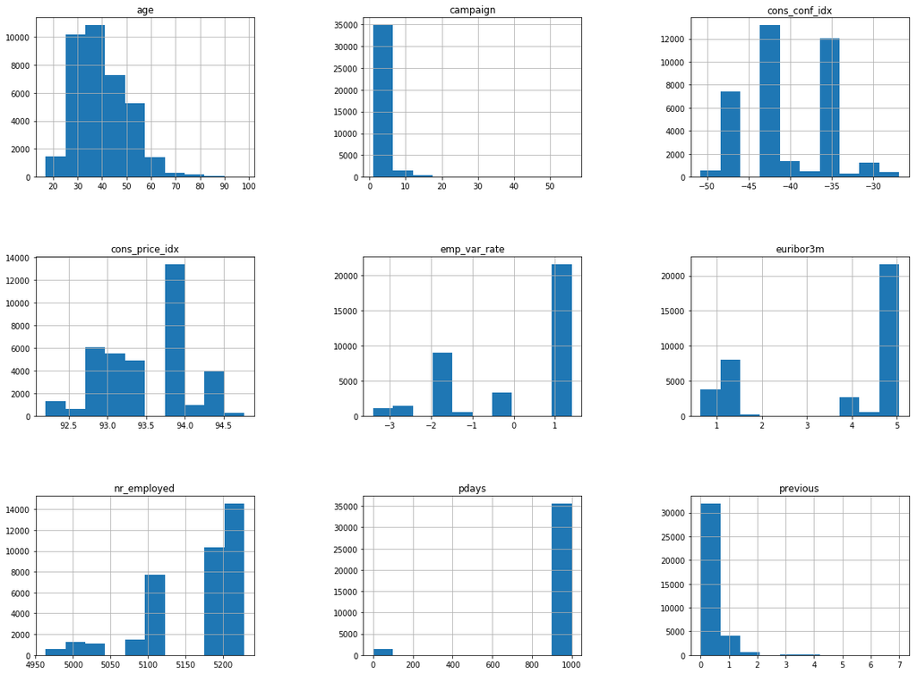

```python
header = ['age','campaign','pdays','previous','emp_var_rate','cons_price_idx','cons_conf_idx','euribor3m','nr_employed']
bank.hist(column=header,figsize=(20,15))
plt.subplots_adjust(wspace = 0.5, hspace = 0.5)
plt.show()
```

#### Visualize the distribution of Categorical Data:

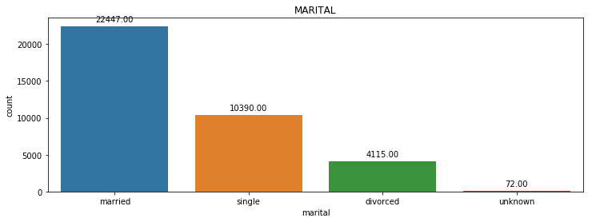

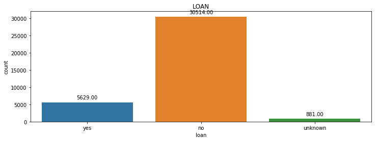

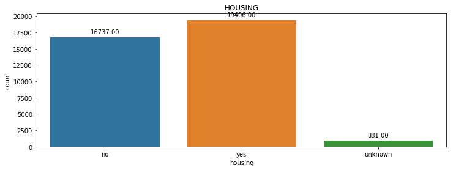

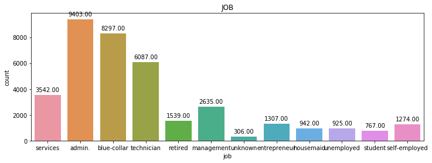

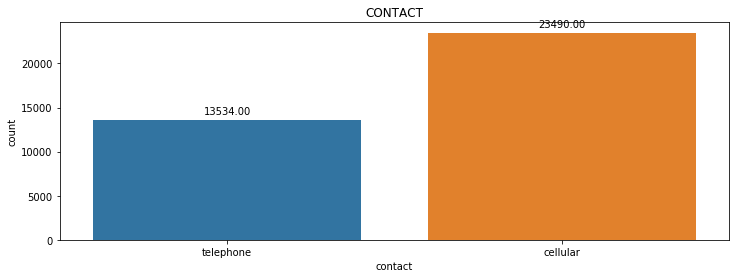

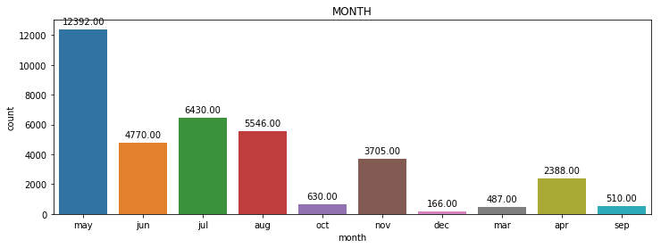

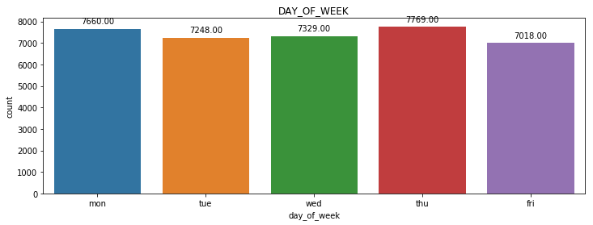

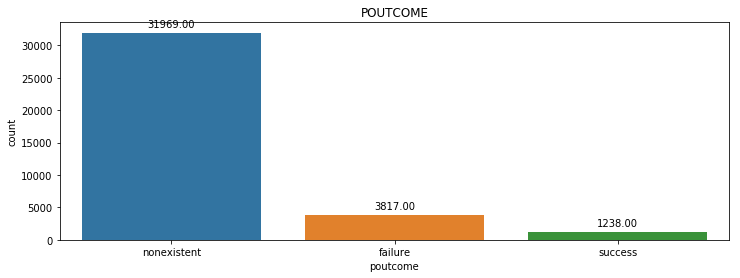

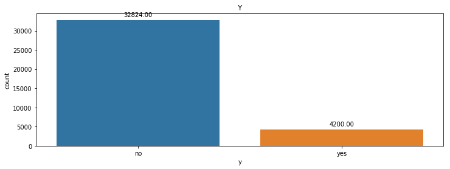

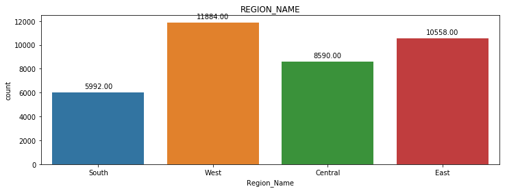

```python
header1 = ['marital','loan','housing','job','contact','month','day_of_week','poutcome','y','Region_Name']
for i in range(0,10):
    plt.figure(figsize = (12, 4))
    ax = sns.countplot(bank[header1[i]])
    plt.title(str(header1[i]).upper())
    for p in ax.patches:
        ax.annotate(format(p.get_height(), '.2f'),
                   (p.get_x() + p.get_width() / 2., p.get_height()),
                   ha = 'center', va = 'center',
                   xytext = (0, 9),
                   textcoords = 'offset points')
```

### Note:

```
From above plots we can see the distribution of the categorical values.
```

# Data Transformation:

```
Missing value treatment, outlier treatment, where ever necessary.
```

### Note:

```
Replacing unknown values as nan as we don't have missing values we will treat unknown values as missing values.
```

```python
import numpy as np
for cols in bank_final.columns:
    bank_final = bank_final.withColumn(cols, \
              when(bank_final[cols] == 'unknown', np.nan).otherwise(bank_final[cols]))
```

```python
bank_final.select([count(when(isnan(c), c)).alias(c) for c in bank_final.columns]).show()
```

```
+-----------+---+---+-------+---------+-------+-------+----+-------+-----+-----------+--------+--------+-----+--------+--------+---+------------+--------------+-------------+---------+-----------+---------+-----------+----------+
|Customer_id|age|job|marital|education|default|housing|loan|contact|month|day_of_week|duration|campaign|pdays|previous|poutcome|  y|emp_var_rate|cons_price_idx|cons_conf_idx|euribor3m|nr_employed|City_Name|Region_Name|State_Name|
+-----------+---+---+-------+---------+-------+-------+----+-------+-----+-----------+--------+--------+-----+--------+--------+---+------------+--------------+-------------+---------+-----------+---------+-----------+----------+
|          0|  0|306|     72|     1544|   7687|    881| 881|      0|    0|          0|       0|       0|    0|       0|       0|  0|           0|             0|            0|        0|          0|        0|          0|         0|
+-----------+---+---+-------+---------+-------+-------+----+-------+-----+-----------+--------+--------+-----+--------+--------+---+------------+--------------+-------------+---------+-----------+---------+-----------+----------+
```

### Note:

```
From here we can see the count of unknown values for their respective column.
```

### Note:

```
 Creating function to calculate the mode of the column:
 And we will replace with the most frequent value in the column for the missing values.
 For the default calumn we will leave it as it is.(Keep the values as unknown)
```

```python
def mode_col(column):
    return bank_final.groupby(column).count().orderBy("count", ascending=False).first()[0]
```

```python
mode_col('job')
```

```
'admin.'
```

```python
header1 = ['job', 'marital','education','housing','loan']
for cols in header1:
    bank_final = bank_final.withColumn(cols, \
              when(bank_final[cols] == 'NaN', mode_col(cols)).otherwise(bank_final[cols]))

bank_final = bank_final.withColumn('default', \
              when(bank_final['default'] == 'NaN', 'unknown').otherwise(bank_final[cols]))
```

```python
bank_final.select([count(when(isnan(c), c)).alias(c) for c in bank_final.columns]).show()
```

```
+-----------+---+---+-------+---------+-------+-------+----+-------+-----+-----------+--------+--------+-----+--------+--------+---+------------+--------------+-------------+---------+-----------+---------+-----------+----------+
|Customer_id|age|job|marital|education|default|housing|loan|contact|month|day_of_week|duration|campaign|pdays|previous|poutcome|  y|emp_var_rate|cons_price_idx|cons_conf_idx|euribor3m|nr_employed|City_Name|Region_Name|State_Name|
+-----------+---+---+-------+---------+-------+-------+----+-------+-----+-----------+--------+--------+-----+--------+--------+---+------------+--------------+-------------+---------+-----------+---------+-----------+----------+
|          0|  0|  0|      0|        0|      0|      0|   0|      0|    0|          0|       0|       0|    0|       0|       0|  0|           0|             0|            0|        0|          0|        0|          0|         0|
+-----------+---+---+-------+---------+-------+-------+----+-------+-----+-----------+--------+--------+-----+--------+--------+---+------------+--------------+-------------+---------+-----------+---------+-----------+----------+
```

### Note:

We can see the columns with lessser no of missing values are replaced by the most frequent value and for the default column we will keep it as unknown.

### Note:

As you can see, all the missing values have been treated.

## Handling Outliers:

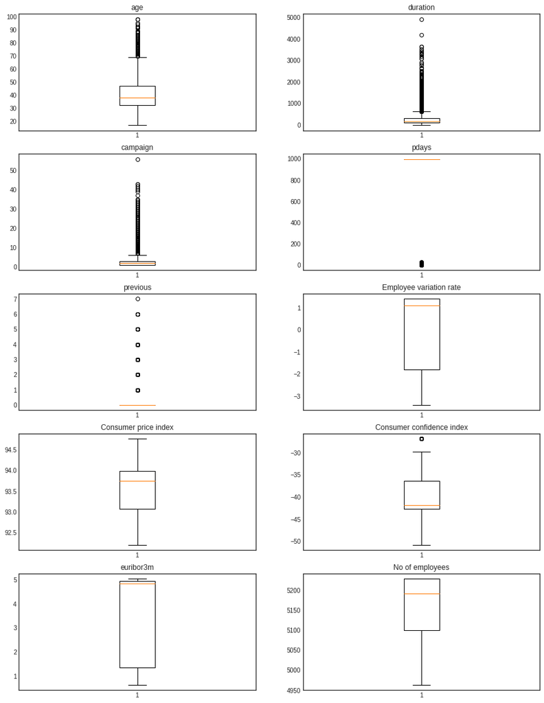

```python
plt.figure(figsize = (15, 20))
plt.style.use('seaborn-white')
ax=plt.subplot(521)
plt.boxplot(bank['age'])
ax.set_title('age')
ax=plt.subplot(522)
plt.boxplot(bank['duration'])
ax.set_title('duration')
ax=plt.subplot(523)
plt.boxplot(bank['campaign'])
ax.set_title('campaign')
ax=plt.subplot(524)
plt.boxplot(bank['pdays'])
ax.set_title('pdays')
ax=plt.subplot(525)
plt.boxplot(bank['previous'])
ax.set_title('previous')
ax=plt.subplot(526)
plt.boxplot(bank['emp_var_rate'])
ax.set_title('Employee variation rate')
ax=plt.subplot(527)
plt.boxplot(bank['cons_price_idx'])
ax.set_title('Consumer price index')
ax=plt.subplot(528)
plt.boxplot(bank['cons_conf_idx'])
ax.set_title('Consumer confidence index')
ax=plt.subplot(529)
plt.boxplot(bank['euribor3m'])
ax.set_title('euribor3m')
ax=plt.subplot(5,2,10)
plt.boxplot(bank['nr_employed'])
ax.set_title('No of employees')
```

## Note:

```
From the above box-plots we can see that there may be presence of outliers in Age, Duration and Campaign column.
But we leave the campaign column as its data points can't be considered as outliers.
```

```python
from pyspark.sql import functions as f


class Outlier():

    def __init__(self, df):
        self.df = df


    def dtypes(self):
        showdf = self.df
        print(self.df.dtypes)

    def _calculate_bounds(self):
        bounds = {
            c: dict(
                zip(["q1", "q3"], self.df.approxQuantile(c, [0.25, 0.80], 0))
            )
            for c, d in zip(self.df.columns, self.df.dtypes) if d[1] in ["double"]
        }

        for c in bounds:
            iqr = bounds[c]['q3'] - bounds[c]['q1']
            bounds[c]['min'] = bounds[c]['q1'] - (iqr * 1.5)
            bounds[c]['max'] = bounds[c]['q3'] + (iqr * 1.5)

        return bounds


    def _flag_outliers_df(self):
        bounds = self._calculate_bounds()

        outliers_col = [
            f.when(
                ~f.col(c).between(bounds[c]['min'], bounds[c]['max']),
                f.col(c)
            ).alias(c + '_outlier')
            for c in bounds]

        return self.df.select(*outliers_col)


    def show_outliers(self):

        outlier_df = self._flag_outliers_df()

        for outlier in outlier_df.columns:
            outlier_df.select(outlier).filter(f.col(outlier).isNotNull()).show()


    def treat_outliers(self,col1):
        bounds = self._calculate_bounds()
        treated_df = self.df.withColumn(
                            col1,
                            f.when((self.df[col1] >bounds[col1]['max']) | (self.df[col1] < bounds [col1]['min']),
                                   f.round(f.lit(self.df.select(f.mean(F.col(col1)).alias('mean')).collect()[0]['mean'])).cast('int') ).otherwise(F.col(col1)))
        return treated_df
```

```python
Outlier(bank_final)._calculate_bounds()
```

```
{'Customer_id': {'max': 60262.0, 'min': -21322.0, 'q1': 9272.0, 'q3': 29668.0},
 'age': {'max': 74.5, 'min': 6.5, 'q1': 32.0, 'q3': 49.0},
 'campaign': {'max': 6.0, 'min': -2.0, 'q1': 1.0, 'q3': 3.0},
 'cons_conf_idx': {'max': -26.950002670288086,
  'min': -52.14999961853027,
  'q1': -42.70000076293945,
  'q3': -36.400001525878906},
 'cons_price_idx': {'max': 95.37251281738281,
  'min': 91.69648742675781,
  'q1': 93.07499694824219,
  'q3': 93.99400329589844},
 'duration': {'max': 767.0, 'min': -297.0, 'q1': 102.0, 'q3': 368.0},
 'emp_var_rate': {'max': 6.1999998688697815,
  'min': -6.599999845027924,
  'q1': -1.7999999523162842,
  'q3': 1.399999976158142},
 'euribor3m': {'max': 10.38899976015091,
  'min': -4.082999885082245,
  'q1': 1.343999981880188,
  'q3': 4.961999893188477},
 'nr_employed': {'max': 5421.60009765625,
  'min': 4905.60009765625,
  'q1': 5099.10009765625,
  'q3': 5228.10009765625},
 'pdays': {'max': 999.0, 'min': 999.0, 'q1': 999.0, 'q3': 999.0},
 'previous': {'max': 0.0, 'min': 0.0, 'q1': 0.0, 'q3': 0.0}}
```

```python
Outlier(bank_final).show_outliers()
```

```
+----------------+
|duration_outlier|
+----------------+
|          1666.0|
|           787.0|
|           812.0|
|          1575.0|
|          1042.0|
|          1467.0|
|           849.0|
|           843.0|
|          1077.0|
|           962.0|
|           935.0|
|          1201.0|
|          1030.0|
|           769.0|
|          1623.0|
|          1677.0|
|           918.0|
|           792.0|
|          1297.0|
|          1906.0|
+----------------+
only showing top 20 rows

+-------------+
|pdays_outlier|
+-------------+
|          6.0|
|          4.0|
|          4.0|
|          3.0|
|          4.0|
|          5.0|
|          5.0|
|          1.0|
|          6.0|
|          4.0|
|          4.0|
```

[output cut: 125 more lines]

```
|             1.0|
|             1.0|
|             1.0|
|             1.0|
|             1.0|
|             1.0|
|             1.0|
|             1.0|
+----------------+
only showing top 20 rows

+-----------------+
|euribor3m_outlier|
+-----------------+
+-----------------+
```

### Note:

We have got the outliers for all the numeric columns but we need only treeat the age and duration outliers. We will leave the rest as it is.

### Note:

```
We will check the max age and duration values before treating them.
```

```python
bank_final.select(f.max(f.col('age'))).show()
```

```
+--------+
|max(age)|
+--------+
|    98.0|
+--------+
```

```python
bank_final.select(f.max(f.col('duration'))).show()
```

```
+-------------+
|max(duration)|
+-------------+
|       4918.0|
+-------------+
```

```python
bank_final = Outlier(bank_final).treat_outliers('age')
bank_final = Outlier(bank_final).treat_outliers('duration')
```

```python
bank_final.select(f.max(f.col('age'))).show()
```

```
+--------+
|max(age)|
+--------+
|    74.0|
+--------+
```

```python
bank_final.select(f.max(f.col('duration'))).show()
```

```
+-------------+
|max(duration)|
+-------------+
|        767.0|
+-------------+
```

### Note:

We can see that the max values have changed for the age and duration column. Thus, we have removed the outliers using IQR method.

```python
Y=bank_final.select(col('y'))
```

```python
for cols in Y.columns:
    bank_final = bank_final.withColumn(cols, \
              when(bank_final[cols] == 'no',0).otherwise(1))
```

```python
bank_final=(bank_final.withColumnRenamed("y","label"))
```

```python
bank_final=bank_final.drop('Customer_id')
```

```python
bank_final.columns
```

```
['age',
 'job',
 'marital',
 'education',
 'default',
 'housing',
 'loan',
 'contact',
 'month',
 'day_of_week',
 'duration',
 'campaign',
 'pdays',
 'previous',
 'poutcome',
 'label',
 'emp_var_rate',
 'cons_price_idx',
 'cons_conf_idx',
 'euribor3m',
 'nr_employed',
 'City_Name',
 'Region_Name',
 'State_Name']
```

```python
cat=['job',
 'marital',
 'education',
 'default',
 'housing',
 'loan',
 'contact',
 'month',
 'day_of_week',
 'poutcome',
 'City_Name',
 'Region_Name',
 'State_Name']
```

```python
from pyspark.ml.feature import StringIndexer
from pyspark.ml import Pipeline

indexers = [StringIndexer(inputCol=cat, outputCol=cat+"_labeled").fit(bank_final) for cat in list(cat) ]


pipeline = Pipeline(stages=indexers)
df_r = pipeline.fit(bank_final).transform(bank_final)
```

```python
for col in cat:
    df_r=df_r.drop(col)
```

```python
features=df_r.columns
features.remove('label')
```

```python
features
```

```
['age',
 'duration',
 'campaign',
 'pdays',
 'previous',
 'emp_var_rate',
 'cons_price_idx',
 'cons_conf_idx',
 'euribor3m',
 'nr_employed',
 'job_labeled',
 'marital_labeled',
 'education_labeled',
 'default_labeled',
 'housing_labeled',
 'loan_labeled',
 'contact_labeled',
 'month_labeled',
 'day_of_week_labeled',
 'poutcome_labeled',
 'City_Name_labeled',
 'Region_Name_labeled',
 'State_Name_labeled']
```

```python
df_r.printSchema()
```

```
root
 |-- age: double (nullable = true)
 |-- duration: double (nullable = true)
 |-- campaign: double (nullable = true)
 |-- pdays: double (nullable = true)
 |-- previous: double (nullable = true)
 |-- label: integer (nullable = false)
 |-- emp_var_rate: double (nullable = true)
 |-- cons_price_idx: double (nullable = true)
 |-- cons_conf_idx: double (nullable = true)
 |-- euribor3m: double (nullable = true)
 |-- nr_employed: double (nullable = true)
 |-- job_labeled: double (nullable = true)
 |-- marital_labeled: double (nullable = true)
 |-- education_labeled: double (nullable = true)
 |-- default_labeled: double (nullable = true)
 |-- housing_labeled: double (nullable = true)
 |-- loan_labeled: double (nullable = true)
 |-- contact_labeled: double (nullable = true)
 |-- month_labeled: double (nullable = true)
 |-- day_of_week_labeled: double (nullable = true)
 |-- poutcome_labeled: double (nullable = true)
 |-- City_Name_labeled: double (nullable = true)
 |-- Region_Name_labeled: double (nullable = true)
 |-- State_Name_labeled: double (nullable = true)
```

```python
(training, test) = df_r.randomSplit([.8, .2])
```

```python
vectorAssembler = VectorAssembler(inputCols=features, outputCol="unscaled_features")
standardScaler = StandardScaler(inputCol="unscaled_features", outputCol="features")
```

Creating a vector of features and scaling it.

```python
normalizer = Normalizer(inputCol='features',outputCol='norm_scaled_features')

gbt = GBTClassifier(labelCol='label', featuresCol="norm_scaled_features" \
                    , maxIter=10 \
                    , maxDepth=7)

pipeline = Pipeline(stages=[vectorAssembler,standardScaler,normalizer, gbt])

pipe_gbt = pipeline.fit(training)

results = pipe_gbt.transform(test)

correct_count = results.filter(results.label == results.prediction).count()
total_count = results.count()

correct_1_count = results.filter((results.label == 1) & (results.prediction == 1)).count()
total_1_test = results.filter((results.label == 1)).count()
total_1_predict = results.filter((results.prediction == 1)).count()

print("All correct predictions count: ",correct_count)
print("Total count: ",total_count)
print("Accuracy %: ",(correct_count / total_count)*100)
print("Recall %: ",(correct_1_count / total_1_test)*100)
print("Precision %: ",(correct_1_count / total_1_predict)*100)
```

```
All correct predictions count:  6709
Total count:  7357
Accuracy %:  91.19206198178605
Recall %:  47.91929382093317
Precision %:  61.78861788617886
```

The model was run for a depth of 7 with 10 iterations. Around 91% accuracy was achieved.